# LoanPrediction

```python
cd "E:\SS\CaseProblem -LoanPrediction"
```

```
E:\SS\CaseProblem -LoanPrediction
```

```python
import pandas as pd
import numpy as np
data = pd.read_csv("train.csv", index_col="Loan_ID")
data
```

| Loan_ID | Gender | Married | Dependents | Education | Self_Employed | ApplicantIncome | CoapplicantIncome | LoanAmount | Loan_Amount_Term | Credit_History | Property_Area | Loan_Status |
| --- | --- | --- | --- | --- | --- | --- | --- | --- | --- | --- | --- | --- |
| LP001002 | Male | No | 0 | Graduate | No | 5849 | 0 | NaN | 360 | 1 | Urban | Y |
| LP001003 | Male | Yes | 1 | Graduate | No | 4583 | 1508 | 128 | 360 | 1 | Rural | N |
| LP001005 | Male | Yes | 0 | Graduate | Yes | 3000 | 0 | 66 | 360 | 1 | Urban | Y |
| LP001006 | Male | Yes | 0 | Not Graduate | No | 2583 | 2358 | 120 | 360 | 1 | Urban | Y |
| LP001008 | Male | No | 0 | Graduate | No | 6000 | 0 | 141 | 360 | 1 | Urban | Y |
| LP001011 | Male | Yes | 2 | Graduate | Yes | 5417 | 4196 | 267 | 360 | 1 | Urban | Y |
| LP001013 | Male | Yes | 0 | Not Graduate | No | 2333 | 1516 | 95 | 360 | 1 | Urban | Y |
| LP001014 | Male | Yes | 3+ | Graduate | No | 3036 | 2504 | 158 | 360 | 0 | Semiurban | N |
| LP001018 | Male | Yes | 2 | Graduate | No | 4006 | 1526 | 168 | 360 | 1 | Urban | Y |
| LP001020 | Male | Yes | 1 | Graduate | No | 12841 | 10968 | 349 | 360 | 1 | Semiurban | N |
| LP001024 | Male | Yes | 2 | Graduate | No | 3200 | 700 | 70 | 360 | 1 | Urban | Y |
| LP001027 | Male | Yes | 2 | Graduate | NaN | 2500 | 1840 | 109 | 360 | 1 | Urban | Y |
| LP001028 | Male | Yes | 2 | Graduate | No | 3073 | 8106 | 200 | 360 | 1 | Urban | Y |
| LP001029 | Male | No | 0 | Graduate | No | 1853 | 2840 | 114 | 360 | 1 | Rural | N |
| LP001030 | Male | Yes | 2 | Graduate | No | 1299 | 1086 | 17 | 120 | 1 | Urban | Y |
| LP001032 | Male | No | 0 | Graduate | No | 4950 | 0 | 125 | 360 | 1 | Urban | Y |
| LP001034 | Male | No | 1 | Not Graduate | No | 3596 | 0 | 100 | 240 | NaN | Urban | Y |
| LP001036 | Female | No | 0 | Graduate | No | 3510 | 0 | 76 | 360 | 0 | Urban | N |
| LP001038 | Male | Yes | 0 | Not Graduate | No | 4887 | 0 | 133 | 360 | 1 | Rural | N |
| LP001041 | Male | Yes | 0 | Graduate | NaN | 2600 | 3500 | 115 | NaN | 1 | Urban | Y |
| LP001043 | Male | Yes | 0 | Not Graduate | No | 7660 | 0 | 104 | 360 | 0 | Urban | N |
| LP001046 | Male | Yes | 1 | Graduate | No | 5955 | 5625 | 315 | 360 | 1 | Urban | Y |
| LP001047 | Male | Yes | 0 | Not Graduate | No | 2600 | 1911 | 116 | 360 | 0 | Semiurban | N |
| LP001050 | NaN | Yes | 2 | Not Graduate | No | 3365 | 1917 | 112 | 360 | 0 | Rural | N |
| LP001052 | Male | Yes | 1 | Graduate | NaN | 3717 | 2925 | 151 | 360 | NaN | Semiurban | N |
| LP001066 | Male | Yes | 0 | Graduate | Yes | 9560 | 0 | 191 | 360 | 1 | Semiurban | Y |
| LP001068 | Male | Yes | 0 | Graduate | No | 2799 | 2253 | 122 | 360 | 1 | Semiurban | Y |
| LP001073 | Male | Yes | 2 | Not Graduate | No | 4226 | 1040 | 110 | 360 | 1 | Urban | Y |
| LP001086 | Male | No | 0 | Not Graduate | No | 1442 | 0 | 35 | 360 | 1 | Urban | N |
| LP001087 | Female | No | 2 | Graduate | NaN | 3750 | 2083 | 120 | 360 | 1 | Semiurban | Y |
| ... | ... | ... | ... | ... | ... | ... | ... | ... | ... | ... | ... | ... |
| LP002911 | Male | Yes | 1 | Graduate | No | 2787 | 1917 | 146 | 360 | 0 | Rural | N |
| LP002912 | Male | Yes | 1 | Graduate | No | 4283 | 3000 | 172 | 84 | 1 | Rural | N |
| LP002916 | Male | Yes | 0 | Graduate | No | 2297 | 1522 | 104 | 360 | 1 | Urban | Y |
| LP002917 | Female | No | 0 | Not Graduate | No | 2165 | 0 | 70 | 360 | 1 | Semiurban | Y |
| LP002925 | NaN | No | 0 | Graduate | No | 4750 | 0 | 94 | 360 | 1 | Semiurban | Y |
| LP002926 | Male | Yes | 2 | Graduate | Yes | 2726 | 0 | 106 | 360 | 0 | Semiurban | N |
| LP002928 | Male | Yes | 0 | Graduate | No | 3000 | 3416 | 56 | 180 | 1 | Semiurban | Y |
| LP002931 | Male | Yes | 2 | Graduate | Yes | 6000 | 0 | 205 | 240 | 1 | Semiurban | N |
| LP002933 | NaN | No | 3+ | Graduate | Yes | 9357 | 0 | 292 | 360 | 1 | Semiurban | Y |
| LP002936 | Male | Yes | 0 | Graduate | No | 3859 | 3300 | 142 | 180 | 1 | Rural | Y |
| LP002938 | Male | Yes | 0 | Graduate | Yes | 16120 | 0 | 260 | 360 | 1 | Urban | Y |
| LP002940 | Male | No | 0 | Not Graduate | No | 3833 | 0 | 110 | 360 | 1 | Rural | Y |
| LP002941 | Male | Yes | 2 | Not Graduate | Yes | 6383 | 1000 | 187 | 360 | 1 | Rural | N |
| LP002943 | Male | No | NaN | Graduate | No | 2987 | 0 | 88 | 360 | 0 | Semiurban | N |
| LP002945 | Male | Yes | 0 | Graduate | Yes | 9963 | 0 | 180 | 360 | 1 | Rural | Y |
| LP002948 | Male | Yes | 2 | Graduate | No | 5780 | 0 | 192 | 360 | 1 | Urban | Y |
| LP002949 | Female | No | 3+ | Graduate | NaN | 416 | 41667 | 350 | 180 | NaN | Urban | N |
| LP002950 | Male | Yes | 0 | Not Graduate | NaN | 2894 | 2792 | 155 | 360 | 1 | Rural | Y |
| LP002953 | Male | Yes | 3+ | Graduate | No | 5703 | 0 | 128 | 360 | 1 | Urban | Y |
| LP002958 | Male | No | 0 | Graduate | No | 3676 | 4301 | 172 | 360 | 1 | Rural | Y |
| LP002959 | Female | Yes | 1 | Graduate | No | 12000 | 0 | 496 | 360 | 1 | Semiurban | Y |
| LP002960 | Male | Yes | 0 | Not Graduate | No | 2400 | 3800 | NaN | 180 | 1 | Urban | N |
| LP002961 | Male | Yes | 1 | Graduate | No | 3400 | 2500 | 173 | 360 | 1 | Semiurban | Y |
| LP002964 | Male | Yes | 2 | Not Graduate | No | 3987 | 1411 | 157 | 360 | 1 | Rural | Y |
| LP002974 | Male | Yes | 0 | Graduate | No | 3232 | 1950 | 108 | 360 | 1 | Rural | Y |
| LP002978 | Female | No | 0 | Graduate | No | 2900 | 0 | 71 | 360 | 1 | Rural | Y |
| LP002979 | Male | Yes | 3+ | Graduate | No | 4106 | 0 | 40 | 180 | 1 | Rural | Y |
| LP002983 | Male | Yes | 1 | Graduate | No | 8072 | 240 | 253 | 360 | 1 | Urban | Y |
| LP002984 | Male | Yes | 2 | Graduate | No | 7583 | 0 | 187 | 360 | 1 | Urban | Y |
| LP002990 | Female | No | 0 | Graduate | Yes | 4583 | 0 | 133 | 360 | 0 | Semiurban | N |

614 rows × 12 columns

we want a list of all females who are not graduate and got a loan. Boolean indexing can help here.

```python
data.loc[(data["Gender"]=="Female") & (data["Education"]=="Not Graduate") & (data["Loan_Status"]=="Y"),
         ["Gender","Education","Loan_Status"]]
```

| Loan_ID | Gender | Education | Loan_Status |
| --- | --- | --- | --- |
| LP001155 | Female | Not Graduate | Y |
| LP001669 | Female | Not Graduate | Y |
| LP001692 | Female | Not Graduate | Y |
| LP001908 | Female | Not Graduate | Y |
| LP002300 | Female | Not Graduate | Y |
| LP002314 | Female | Not Graduate | Y |
| LP002407 | Female | Not Graduate | Y |
| LP002489 | Female | Not Graduate | Y |
| LP002502 | Female | Not Graduate | Y |
| LP002534 | Female | Not Graduate | Y |
| LP002582 | Female | Not Graduate | Y |
| LP002731 | Female | Not Graduate | Y |
| LP002757 | Female | Not Graduate | Y |
| LP002917 | Female | Not Graduate | Y |

Apply returns some value after passing each row/column of a data frame with some function. The function can be both default or user-defined. For instance, here it can be used to find the #missing values in each row and column.

```python
#Create a new function:
def num_missing(x):
    return sum(x.isnull())

#Applying per column:
print "Missing values per column:"
print data.apply(num_missing, axis=0) #axis=0 defines that function is to be applied on each column

#Applying per row:
print "\nMissing values per row:"
print data.apply(num_missing, axis=1).head() #axis=1 defines that function is to be applied on each row
```

```
Missing values per column:
Gender               13
Married               3
Dependents           15
Education             0
Self_Employed        32
ApplicantIncome       0
CoapplicantIncome     0
LoanAmount           22
Loan_Amount_Term     14
Credit_History       50
Property_Area         0
Loan_Status           0
dtype: int64

Missing values per row:
Loan_ID
LP001002    1
LP001003    0
LP001005    0
LP001006    0
LP001008    0
dtype: int64
```

### Imputing missing files

‘fillna()’ does it in one go. It is used for updating missing values with the overall mean/mode/median of the column. Let’s impute the ‘Gender’, ‘Married’ and ‘Self_Employed’ columns with their respective modes.

```python
#First we import a function to determine the mode
from scipy.stats import mode
mode(data['Gender'])
```

```
C:\Users\paushali\AppData\Local\Dato\Dato Launcher\lib\site-packages\numpy\lib\arraysetops.py:198: FutureWarning: numpy not_equal will not check object identity in the future. The comparison did not return the same result as suggested by the identity (`is`)) and will change.
  flag = np.concatenate(([True], aux[1:] != aux[:-1]))
```

```
(array(['Male'], dtype=object), array([ 489.]))
```

This returns both mode and count. Remember that mode can be an array as there can be multiple values with high frequency. We will take the first one by default always using:

```python
type(mode(data['Gender']))
```

```
tuple
```

```python
mode(data['Gender'])[0][0]
```

```
'Male'
```

```python
#Impute the values:
data['Gender'].fillna(mode(data['Gender'])[0][0], inplace=True)
data['Married'].fillna(mode(data['Married'])[0][0], inplace=True)
data['Self_Employed'].fillna(mode(data['Self_Employed'])[0][0], inplace=True)
```

```python
#Now check the #missing values again to confirm:
print data.apply(num_missing, axis=0)
```

```
Gender                0
Married               0
Dependents           15
Education             0
Self_Employed         0
ApplicantIncome       0
CoapplicantIncome     0
LoanAmount           22
Loan_Amount_Term     14
Credit_History       50
Property_Area         0
Loan_Status           0
dtype: int64
```

### Pivot Table

Pandas can be used to create MS Excel style pivot tables. For instance, in this case, a key column is “LoanAmount” which has missing values. We can impute it using mean amount of each ‘Gender’, ‘Married’ and ‘Self_Employed’ group. The mean ‘LoanAmount’ of each group can be determined as:

```python
#Determine pivot table
impute_grps = data.pivot_table(values=["LoanAmount"], index=["Gender","Married","Self_Employed"], aggfunc=np.mean)
print impute_grps
```

```
                              LoanAmount
Gender Married Self_Employed
Female No      No             114.691176
               Yes            125.800000
       Yes     No             134.222222
               Yes            282.250000
Male   No      No             129.936937
               Yes            180.588235
       Yes     No             153.882736
               Yes            169.395833
```

### Multi-Indexing

```python
for i,row in data.loc[data['LoanAmount'].isnull(),:].iterrows():
    ind=tuple([row['Gender'],row['Married'],row['Self_Employed']])
    data.loc[i,'LoanAmount']
print ind
print data.loc[:,'LoanAmount']
```

```
('Male', 'Yes', 'No')
Loan_ID
LP001002    NaN
LP001003    128
LP001005     66
LP001006    120
LP001008    141
LP001011    267
LP001013     95
LP001014    158
LP001018    168
LP001020    349
LP001024     70
LP001027    109
LP001028    200
LP001029    114
LP001030     17
LP001032    125
LP001034    100
LP001036     76
LP001038    133
LP001041    115
LP001043    104
LP001046    315
LP001047    116
LP001050    112
LP001052    151
LP001066    191
LP001068    122
LP001073    110
LP001086     35
LP001087    120
           ...
LP002911    146
LP002912    172
LP002916    104
LP002917     70
LP002925     94
LP002926    106
LP002928     56
```

[output cut: 9 more lines]

```
LP002949    350
LP002950    155
LP002953    128
LP002958    172
LP002959    496
LP002960    NaN
LP002961    173
LP002964    157
LP002974    108
LP002978     71
LP002979     40
LP002983    253
LP002984    187
LP002990    133
Name: LoanAmount, dtype: float64
```

### Crosstab

This function is used to get an initial “feel” (view) of the data. Here, we can validate some basic hypothesis. For instance, in this case, “Credit_History” is expected to affect the loan status significantly. This can be tested using cross-tabulation as shown below:

```python
pd.crosstab(data["Credit_History"],data["Loan_Status"],margins=True)
```

| Loan_Status Credit_History | N | Y | All |
| --- | --- | --- | --- |
| 0.0 | 82 | 7 | 89 |
| 1.0 | 97 | 378 | 475 |
| All | 192 | 422 | 614 |

```python
#These are absolute numbers. But, percentages can be more intuitive in making some quick insights.
#We can do this using the apply function:
def percConvert(ser):
    return ser/float(ser[-1])
pd.crosstab(data["Credit_History"],data["Loan_Status"],margins=True).apply(percConvert, axis=1)
```

| Loan_Status Credit_History | N | Y | All |
| --- | --- | --- | --- |
| 0.0 | 0.921348 | 0.078652 | 1 |
| 1.0 | 0.204211 | 0.795789 | 1 |
| All | 0.312704 | 0.687296 | 1 |

```python
print 82/float(89)
print 97/float(475)
```

```
0.921348314607
0.204210526316
```

```python
a=[30,40,50]
a[-1]
```

```
50
```

### Merge DataFrames

Merging dataframes become essential when we have information coming from different sources to be collated. Consider a hypothetical case where the average property rates (INR per sq meters) is available for different property types. Let’s define a dataframe as:

```python
prop_rates = pd.DataFrame([1000, 5000, 12000], index=['Rural','Semiurban','Urban'],columns=['rates'])
prop_rates
```

|  | rates |
| --- | --- |
| Rural | 1000 |
| Semiurban | 5000 |
| Urban | 12000 |

```python
#Now we can merge this information with the original dataframe as:
data_merged = data.merge(right=prop_rates, how='inner',left_on='Property_Area',right_index=True, sort=False)
data_merged.pivot_table(values='Credit_History',index=['Property_Area','rates'], aggfunc=len)
#The pivot table validates successful merge operation. Note that the ‘values’ argument is irrelevant here
#because we are simply counting the values.
```

```
Property_Area  rates
Rural          1000     179
Semiurban      5000     233
Urban          12000    202
Name: Credit_History, dtype: float64
```

### Sorting DataFrames

Pandas allow easy sorting based on multiple columns. This can be done as:

```python
data
data_sorted = data.sort(['ApplicantIncome','CoapplicantIncome'], ascending=False)
data_sorted[['ApplicantIncome','CoapplicantIncome']].head(10)
```

| Loan_ID | ApplicantIncome | CoapplicantIncome |
| --- | --- | --- |
| LP002317 | 81000 | 0 |
| LP002101 | 63337 | 0 |
| LP001585 | 51763 | 0 |
| LP001536 | 39999 | 0 |
| LP001640 | 39147 | 4750 |
| LP002422 | 37719 | 0 |
| LP001637 | 33846 | 0 |
| LP001448 | 23803 | 0 |
| LP002624 | 20833 | 6667 |
| LP001922 | 20667 | 0 |

### Plotting (Boxplot & Histogram)

Many of you might be unaware that boxplots and histograms can be directly plotted in Pandas and calling matplotlib separately is not necessary. It’s just a 1-line command. For instance, if we want to compare the distribution of ApplicantIncome by Loan_Status:

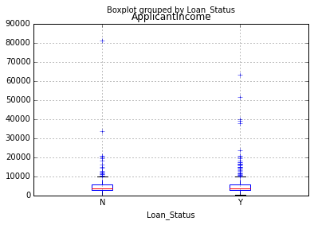

```python
import matplotlib.pyplot as plt
%matplotlib inline
data.boxplot(column="ApplicantIncome",by="Loan_Status")
```

[output not shown]

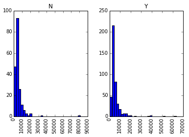

```python
data.hist(column="ApplicantIncome",by="Loan_Status",bins=30)
#This shows that income is not a big deciding factor on its own as there is no appreciable difference
#between the people who received and were denied the loan.
```

### Cut function for binning

Sometimes numerical values make more sense if clustered together. For example, if we’re trying to model traffic (#cars on road) with time of the day (minutes). The exact minute of an hour might not be that relevant for predicting traffic as compared to actual period of the day like “Morning”, “Afternoon”, “Evening”, “Night”, “Late Night”. Modeling traffic this way will be more intuitive and will avoid overfitting. Here we define a simple function which can be re-used for binning any variable fairly easily.

```python
#Binning:
def binning(col, cut_points, labels=None):
  #Define min and max values:
  minval = col.min()
  maxval = col.max()

  #create list by adding min and max to cut_points
  break_points = [minval] + cut_points + [maxval]

  #if no labels provided, use default labels 0 ... (n-1)
  if not labels:
    labels = range(len(cut_points)+1)

  #Binning using cut function of pandas
  colBin = pd.cut(col,bins=break_points,right=False,labels=labels,include_lowest=True)
  return colBin

#Binning age:
cut_points = [90,140,190]
labels = ["low","medium","high","very high"]
data["LoanAmount_Bin"] = binning(data["LoanAmount"], cut_points, labels)
print pd.value_counts(data["LoanAmount_Bin"], sort=False)
```

```
low           98
medium       266
high         136
very high     91
dtype: int64
```

```python
range(len(cut_points)+1)
```

```
[0, 1, 2, 3]
```